# Social predation in a nudibranch mollusc: Figures

Kate Otter

2024-07-01

## Introduction

This Rmarkdown document is for reproducing the figures from the paper “Social predation in a nudibranch mollusc” (2024). Each section will be named in accordance with the figure from the paper where the statistical test was used. The legend text accompanies each panel.

Required data folders are located in the repository data file and the simulated data is in the repository analysis folder.

#### Figure theme:

```r
figure_theme <- function(){
  font <- "sans"   #assign font family up front
  theme_minimal() %+replace%    #replace elements we want to change
    theme(
      #background
      panel.background = element_rect(fill='white', color = NA),
      plot.background = element_rect(fill='white', color=NA),
      #grid elements
      panel.grid.major = element_blank(),
      panel.grid.minor = element_blank(),
      axis.line = element_line(color = "black"),
      axis.ticks = element_line(color = "black"),
      plot.title = element_text(hjust = 0.5),
      #text elements
      text = element_text(size = 7),
      axis.title.y = element_text(             #axis titles
        color = "black",
        family = font,
        size = 8,
        angle = 90,
        vjust = 1.5),               #font size
      axis.title.x = element_text(             #axis titles
        color = "black",
        family = font,
        size = 8),               #font size
      axis.text = element_text( #axis text
        color = "black",
        family = font,
        size = 7)               #font size
    )
}
theme_set(figure_theme())
```

### Fig. 1 *Berghia stephanieae* form

groups larger than if they each selected an anemone independently of each other

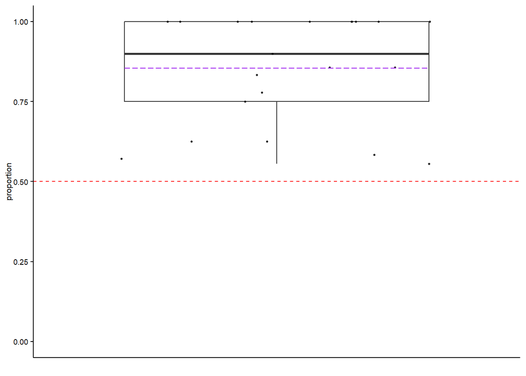

**C** A boxplot of the proportion of slugs feeding on one of the two provided anemones. The slugs did not distribute evenly between the two anemones and tended to form large groups around one of them (Z = 231, p = 0.0000258). Purple line represents the mean. Red dashed line represents even distribution between the anemones.

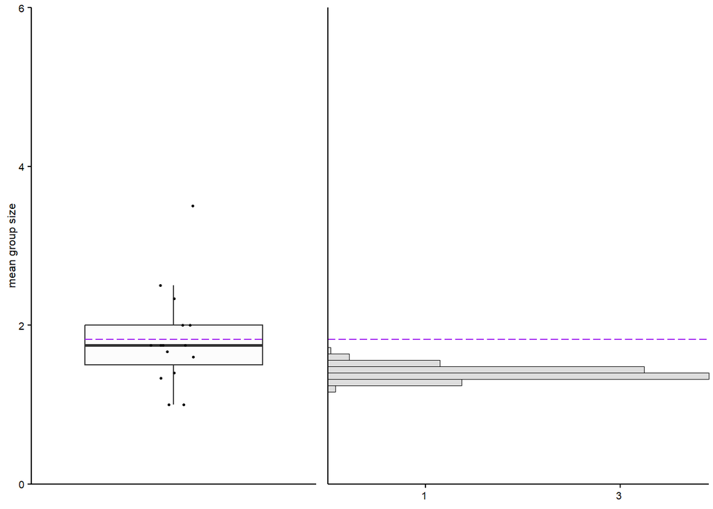

**E** A boxplot representing the mean group sizes observed in each trial (left) and a histogram of the mean group sizes for each simulated dataset with the same number of trials as the experimental data of the null hypothesis where each slug selects an anemone independently of each other (right). The purple dashed line represents the mean group size of the experimental dataset. The observed mean does not occur within the distribution of the simulated data.

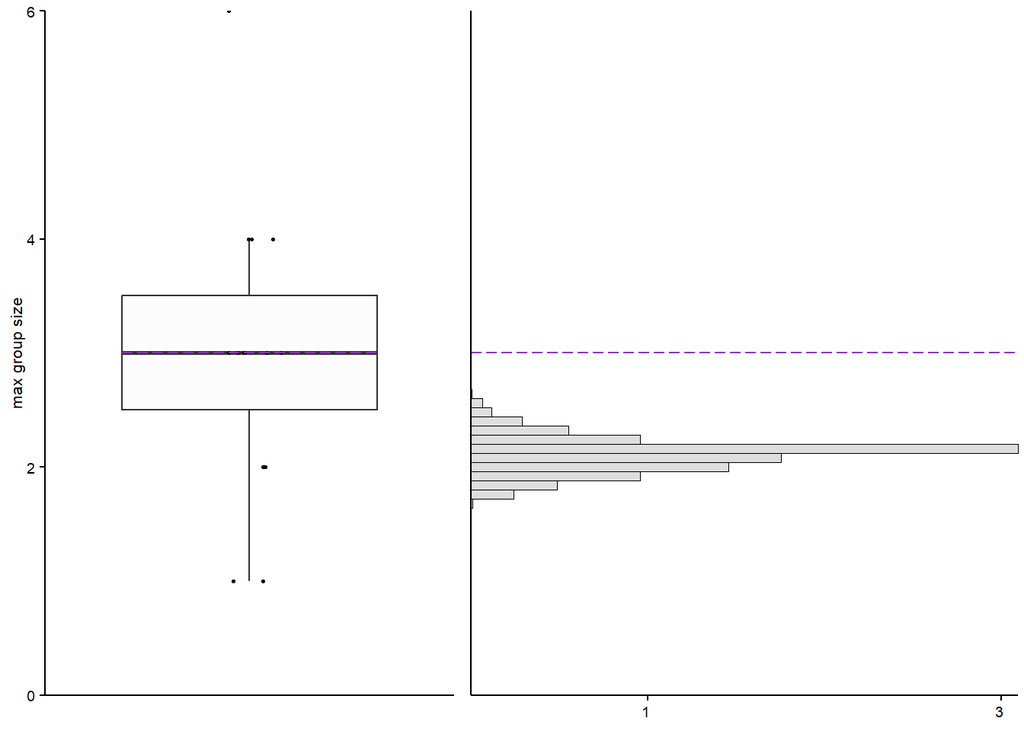

**F** The same plots as **E**, using the maximum group size observed. Similarly, the observed mean of the max group sizes in the dataset does not occur in the simulated data. The simulated data sets have units of 10,000 datasets.

### Fig. 2 Behavior in 2-alternative choice tasks.

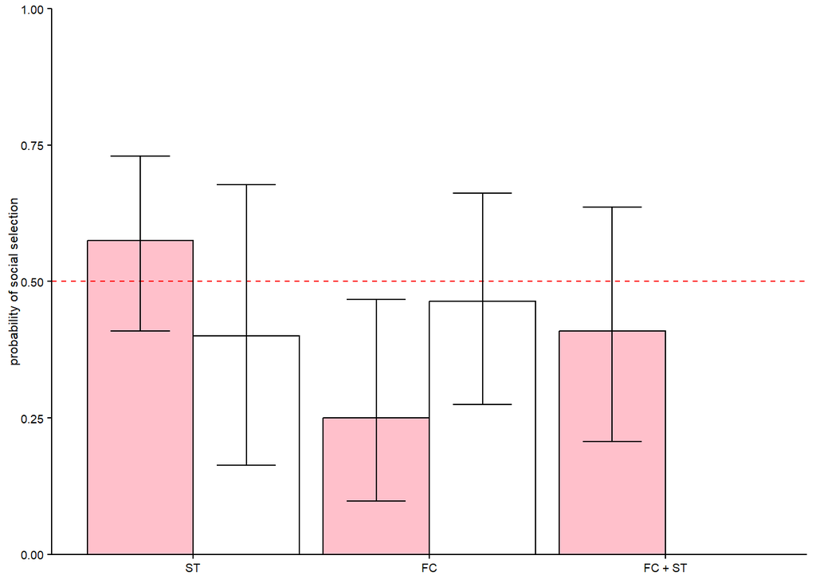

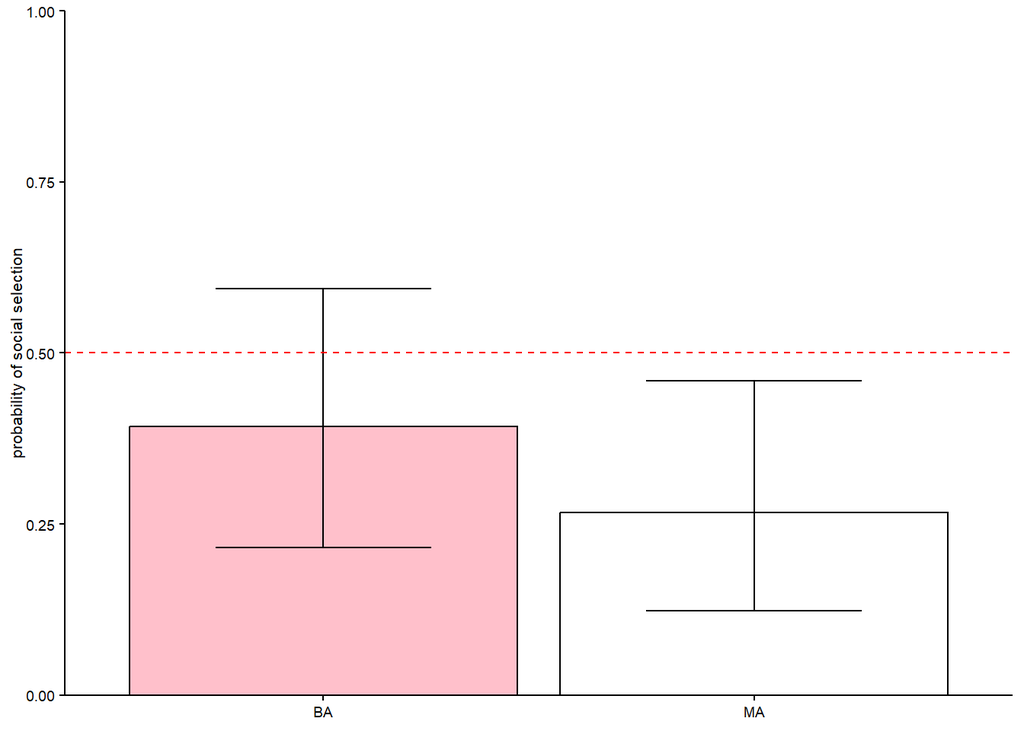

### Fig. 3 There is no difference in group size between

intermediately food-deprived animals and 7-day food-deprived animals

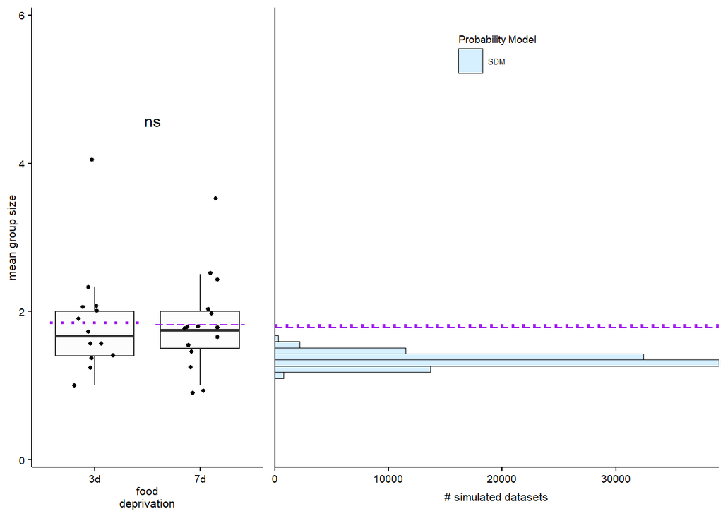

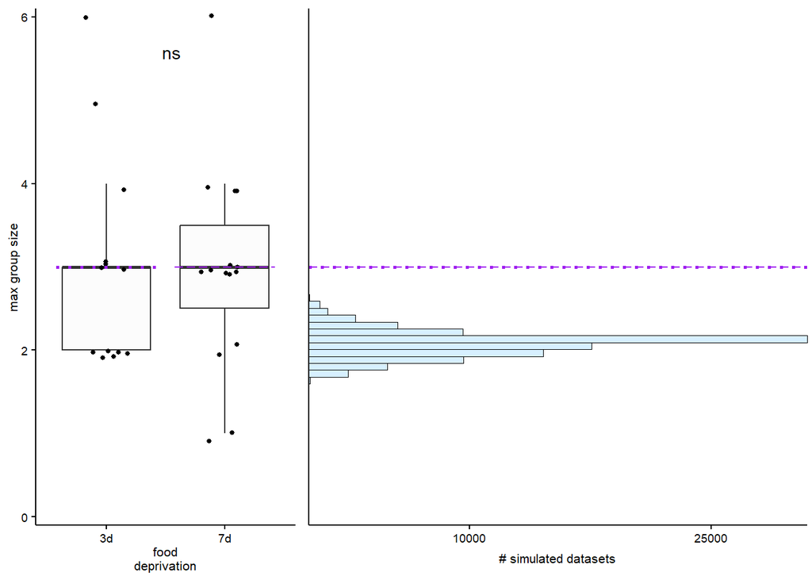

**B** Similar plots as A for the dataset mean of the maximum group sizes.

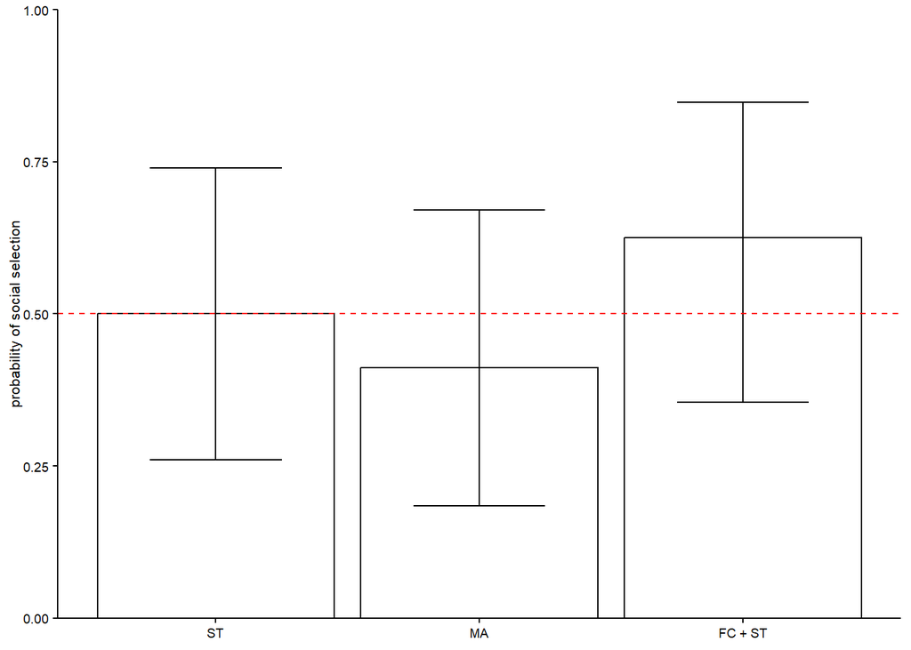

**C** The probability of selecting the manipulated anemone in 2-alternative choice assays comparing feeding conspecifics and slime trails (FC + ST), anemones previously fed on by a conspecific (MA) and anemones with slime trails (ST). None were significantly different from random chance (0.5).

### Fig. 4 The choice to feed socially is not consistent within individuals

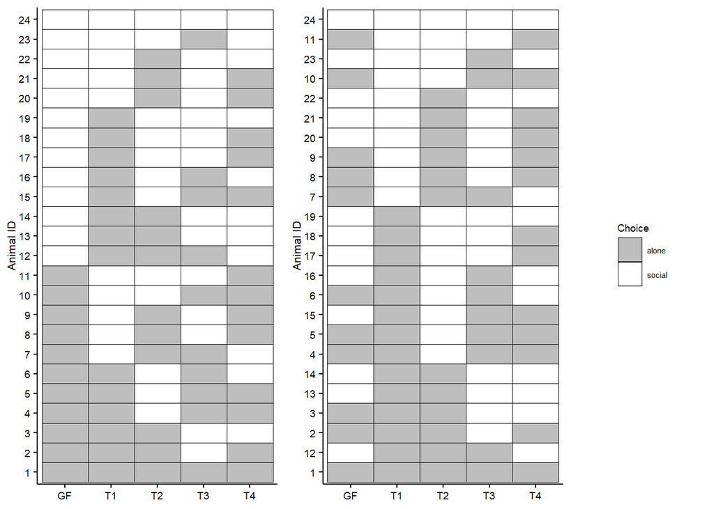

**B** A plot showing the choices of each individual animal in the 5 different assays organized by their choice in the GF assay (left) and their choice in the T1 assay (right).

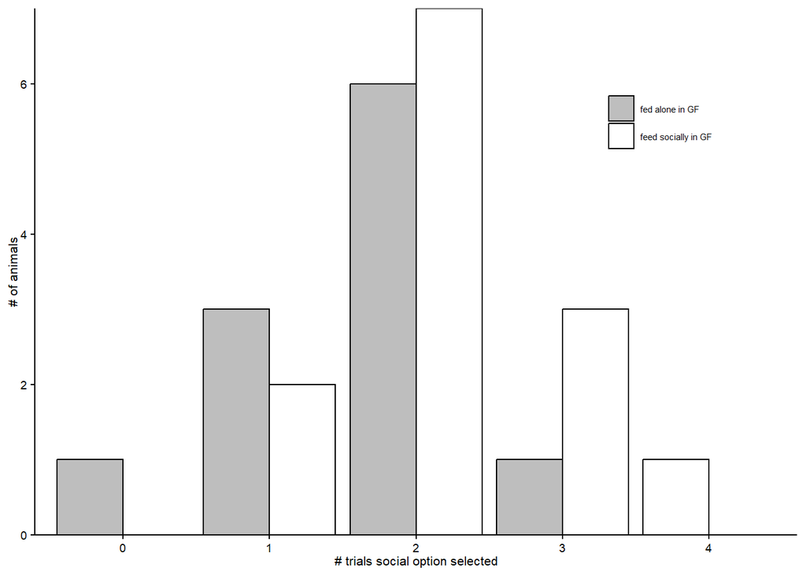